# Textual Analysis of 2016 Philippines’ Presidential Debate

Benjamin Tabares Jr.

April 17, 2016

The recent Philippines’ Presidential Debate (Pilipinas Debates 2016) drew unprecedented amounts of viewers and the usual lot of controversies and soundbites in the media. In our polarized media landscape, ensuing political analysis always suffer from political bias. Whether you trust the media, you will get a very different take on what was said.

So far, the candidates have spoken thousands of words in the two (2) debates held by two TV networks. In this simple textual analysis, I turn all of the words into data and make inferences about the candidates’ characteristics that would otherwise be too difficult to discover.

NLP tools and methods can help bring some objectivity to better understand the current political discourse. Using different state-of-the-art NLP libraries and packages, we will try to answer questions about: Debate Dynamics - What can be inferred about the debaters performances? (FINISHED) Sentiment Analysis - How do the candidates feel about certain issues? (WIP) Topic Modelling - What did the candidates really talked about? (WIP) - What was the most important subject for each candidate?

```r
#set working directory
getwd()
```

```
## [1] "Z:/GitHub/Data Projects/Pilipinas_Debates_2016"
```

```r
setwd("Z:/Github/Data Projects/Pilipinas_Debates_2016/transcripts")
#load required lib
library(tm)
library(SnowballC)
library(wordcloud)
library(RColorBrewer)
```

First let’s answer the following question: how often does a certain candidate get mentioned by name by the other candidates VS how often do the other candidates mention each other’s name. On the first debate, the candidates really didn’t refer to each other much at all.

```r
ref_matrix = function (date){

  #read character data
  text = scan(paste0('debate_', date, '_full', '.txt'), what='x', quote=NULL)

  speakers =
    c(  BINAY    = '',
        MAR   = '',
        DUTERTE  = '',
        MIRIAM  = '',
        POE = ''
    )

  #assign text to the right speaker
  for(word in text){
    #if word ends with :
    if(substr(word,nchar(word),nchar(word))==':'){
      #if word corresponds to one of the speakers of interest
      if(word %in% paste0(names(speakers), ':')){
        #set current speaker
        currentSpeaker = substr(word,1,nchar(word)-1)
      }
      else{
        #if the current speaker is not one of the speakers of interest, set it to NA
        currentSpeaker = NA
      }
    }
    else if(!is.na(currentSpeaker)){
      #if the current speaker is of interest, save what he is saying
      speakers[currentSpeaker] = paste(speakers[currentSpeaker], word)
    }
  }

  #preprocess text
  prez = Corpus(VectorSource(speakers))
  prez = tm_map(prez, tolower)
  prez = tm_map(prez, removeWords,stopwords('english'))
  #remove additional unwanted words
  prez = Corpus(VectorSource(speakers))
  prez = tm_map(prez, tolower)
  prez = tm_map(prez, removeWords,stopwords('english'))
  #remove additional unwanted words
  prez = tm_map(prez, removeWords, c('laughter', 'applause', 'intermission', 'and', 'the', 'all',
                                     'ang','mga','you','hindi','that','kung','ating','said','naman',
                                     'namin','natin','yung','pero','sila','nila','ako','yan','para',
                                     'will','isang','ito','doon','alam','may','kanilang','dahil',
                                     'lahat','have','tayo','kami','for','because','rin','ngayon',
                                     'kaya','kaya','hong','walang','but','kahit','dapat','lang',
                                     'mas','pwedeng','saan','yong','buong','yong','ayaw','lang',
                                     'not','wala','there','are','was','would','ano','well','can',
                                     'kasi','dito','our','akong','with','dun','gusto','ninyo',
                                     'bakit','niya','like','ibang','talagang','did','yes','yun','this',
                                     'anong','man','diyan','tulad','pwede','talaga','give','bilang','isa',
                                     'itong','what','nasa','sinasabi','just','kayo','lamang','nga','luchi',
                                     'mismo','other','akin','kanya','ikaw','cannot','aking','ginawa',
                                     'kanila','ginawa','know','really','sapagkat','din','maraming','they',
                                     'meron','mong','uulitin','yon',
                                     'yon','yo','tony','below','anyway','eto','aba','when','madam','amin',
                                     'nandun','pagka','mahigit','senadora','sya','inyong','parang','salamat',
                                     'senador','nagiging','yeah','look','how','goes','huwag','see','say',
                                     'kang','actually','sinabi','about','mayor','already','nung','importante',
                                     'oras','tama','here','very','into','pati','why','sabi','those','always',
                                     'has','first','ganoon','atin','dalawang','kailangan','papaano','sabihin',
                                     'nilang','hanggang','nating','from','siguro','tayong','naging','after',
                                     'siya','namang','nagsabi','nang','lagi','niyo','grace','nagsasabi','nyo',
                                     'pong','basta','dyan','iyan','pang','tayong','which','should','sino','these',
                                     'without','di','yang','ilang','noon','noong','pag','senator','iyon','kong',
                                     'mag','maging','nandiyan','nang','per','pumunta','iyan','let','muna','each',
                                     'aming','sana','also','basta','ganito'))
  prez = tm_map(prez, removePunctuation,preserve_intra_word_dashes=FALSE)
  prez = tm_map(prez, stemDocument)
  prez = tm_map(prez, stripWhitespace)
  prez = tm_map(prez, removeNumbers)
  prez = tm_map(prez, PlainTextDocument)
  #make document term matrix
  dtm = DocumentTermMatrix(prez)
  #reassign row names (each row is a speaker)
  rownames(dtm) = names(speakers)

  #how many times was VP Jejomar Binay referred to by other candidates
  binay_names = character()
  if('binay' %in% colnames(dtm)){binay_names = c(binay_names, 'binay')}
  if('jejomar' %in% colnames(dtm)){binay_names = c(binay_names, 'jejomar')}
  if('vp' %in% colnames(dtm)){binay_names = c(binay_names, 'vp')}
  if('vice president' %in% colnames(dtm)){binay_names = c(binay_names, 'vice president')}
  dtm_binay = dtm[,binay_names]
  BINAY = apply(dtm_binay, 1, sum)

  #how many times was Mar Roxas referred to by other candidates
  mar_names = character()
  if('mar' %in% colnames(dtm)){mar_names = c(mar_names, 'mar')}
  if('roxas' %in% colnames(dtm)){mar_names = c(mar_names, 'roxas')}
  if('secretary' %in% colnames(dtm)){mar_names = c(mar_names, 'secretary')}
  dtm_mar = dtm[,mar_names]
  MAR = apply(dtm_mar, 1, sum)

  #how many times was Rodrigo Duterte referred to by other candidates
  duterte_names = character()
  if('mayor' %in% colnames(dtm)){duterte_names = c(duterte_names, 'mayor')}
  if('duterte' %in% colnames(dtm)){duterte_names = c(duterte_names, 'duterte')}
  if('rudy' %in% colnames(dtm)){duterte_names = c(duterte_names, 'rudy')}
  if('rodrigo' %in% colnames(dtm)){duterte_names = c(duterte_names, 'rodrigo')}
  dtm_duterte = dtm[,duterte_names]
  DUTERTE = apply(dtm_duterte, 1, sum)

  #how many times was Sen. Miriam Defensor-Santiago referred to by other candidates
  miriam_names = character()
  if('santiago' %in% colnames(dtm)){miriam_names = c(miriam_names, 'santiago')}
  if('miriam' %in% colnames(dtm)){miriam_names = c(miriam_names, 'miriam')}
  dtm_miriam = dtm[,miriam_names]
  MIRIAM = apply(dtm_miriam, 1, sum)

  #how many times was Sen. Grace Poe referred to by other candidates
  poe_names = character()
  if('grace' %in% colnames(dtm)){poe_names = c(poe_names, 'grace')}
  if('poe' %in% colnames(dtm)){poe_names = c(poe_names, 'poe')}
  dtm_poe = dtm[,poe_names]
  POE = apply(dtm_poe, 1, sum)

  #summary matrix
  data.frame(BINAY=BINAY, MAR=MAR, DUTERTE=DUTERTE, MIRIAM=MIRIAM, POE=POE)
}
```

```r
dates = c(20160221,20160320)
ref_list = lapply(dates, ref_matrix)
names(ref_list) = dates
```

On the first debate, the candidates really did not refer to each other much at all. Things change around the second debate, where the candidates refer to each other significantly more. Three (3) candidates stood out that got mentioned by name by the other candidates. Out of these trio, the other candidates collectively referred to Mar more often than they refer to each other. In particular, they throw jabs to each other 13 times in total (light blue bar), where as they ganged-up on Mar 45 times! (dark blue bar)

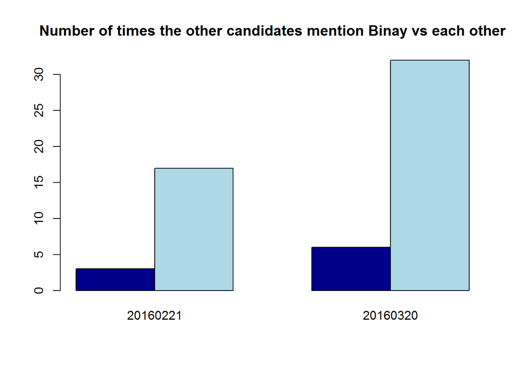

```r
###########################
# First, let's answer the question: How does Binay get mentioned by name by the other four candidates during a debate,
# versus how often do the other candidates mention each other's name?
###########################
binay = sapply(ref_list, function(df) sum(df[rownames(df) != 'BINAY', 'BINAY']))
the_rest = sapply(ref_list, function(df) sum(df[rownames(df) == 'MAR', 'DUTERTE'], df[rownames(df) == 'DUTERTE', 'MAR'],
                                             df[rownames(df) == 'MAR', 'MIRIAM'],df[rownames(df) == 'MIRIAM', 'MAR'],
                                             df[rownames(df) == 'MAR', 'POE'],df[rownames(df) == 'POE', 'MAR'],
                                             df[rownames(df) == 'DUTERTE', 'MIRIAM'],df[rownames(df) == 'MIRIAM', 'DUTERTE'],
                                             df[rownames(df) == 'DUTERTE', 'POE'],df[rownames(df) == 'POE', 'DUTERTE'],
                                             df[rownames(df) == 'MIRIAM', 'POE'],df[rownames(df) == 'POE', 'MIRIAM']))
m = t(as.matrix(data.frame(binay, the_rest)))
# MAR
mar = sapply(ref_list, function(df) sum(df[rownames(df) != 'MAR', 'MAR']))
the_rest = sapply(ref_list, function(df) sum(df[rownames(df) == 'BINAY', 'DUTERTE'], df[rownames(df) == 'DUTERTE', 'BINAY'],
                                             df[rownames(df) == 'BINAY', 'MIRIAM'],df[rownames(df) == 'MIRIAM', 'BINAY'],
                                             df[rownames(df) == 'BINAY', 'POE'],df[rownames(df) == 'POE', 'BINAY'],
                                             df[rownames(df) == 'DUTERTE', 'MIRIAM'],df[rownames(df) == 'MIRIAM', 'DUTERTE'],
                                             df[rownames(df) == 'DUTERTE', 'POE'],df[rownames(df) == 'POE', 'DUTERTE'],
                                             df[rownames(df) == 'MIRIAM', 'POE'],df[rownames(df) == 'POE', 'MIRIAM']))
n = t(as.matrix(data.frame(mar, the_rest)))
# DUTERTE
duterte = sapply(ref_list, function(df) sum(df[rownames(df) != 'DUTERTE', 'DUTERTE']))
the_rest = sapply(ref_list, function(df) sum(df[rownames(df) == 'BINAY', 'MAR'], df[rownames(df) == 'MAR', 'BINAY'],
                                             df[rownames(df) == 'BINAY', 'MIRIAM'],df[rownames(df) == 'MIRIAM', 'BINAY'],
                                             df[rownames(df) == 'BINAY', 'POE'],df[rownames(df) == 'POE', 'BINAY'],
                                             df[rownames(df) == 'MAR', 'MIRIAM'],df[rownames(df) == 'MIRIAM', 'MAR'],
                                             df[rownames(df) == 'MAR', 'POE'],df[rownames(df) == 'POE', 'MAR'],
                                             df[rownames(df) == 'MIRIAM', 'POE'],df[rownames(df) == 'POE', 'MIRIAM']))
o = t(as.matrix(data.frame(duterte, the_rest)))
# POE
poe = sapply(ref_list, function(df) sum(df[rownames(df) != 'POE', 'POE']))
the_rest = sapply(ref_list, function(df) sum(df[rownames(df) == 'BINAY', 'MAR'], df[rownames(df) == 'MAR', 'BINAY'],
                                             df[rownames(df) == 'BINAY', 'MIRIAM'],df[rownames(df) == 'MIRIAM', 'BINAY'],
                                             df[rownames(df) == 'BINAY', 'DUTERTE'],df[rownames(df) == 'DUTERTE', 'BINAY'],
                                             df[rownames(df) == 'MAR', 'MIRIAM'],df[rownames(df) == 'MIRIAM', 'MAR'],
                                             df[rownames(df) == 'MAR', 'DUTERTE'],df[rownames(df) == 'DUTERTE', 'MAR'],
                                             df[rownames(df) == 'MIRIAM', 'DUTERTE'],df[rownames(df) == 'DUTERTE', 'MIRIAM']))
p = t(as.matrix(data.frame(poe, the_rest)))
# MIRIAM
miriam = sapply(ref_list, function(df) sum(df[rownames(df) != 'MIRIAM', 'MIRIAM']))
the_rest = sapply(ref_list, function(df) sum(df[rownames(df) == 'BINAY', 'MAR'], df[rownames(df) == 'MAR', 'BINAY'],
                                             df[rownames(df) == 'BINAY', 'POE'],df[rownames(df) == 'POE', 'BINAY'],
                                             df[rownames(df) == 'BINAY', 'DUTERTE'],df[rownames(df) == 'DUTERTE', 'BINAY'],
                                             df[rownames(df) == 'MAR', 'POE'],df[rownames(df) == 'POE', 'MAR'],
                                             df[rownames(df) == 'MAR', 'DUTERTE'],df[rownames(df) == 'DUTERTE', 'MAR'],
                                             df[rownames(df) == 'POE', 'DUTERTE'],df[rownames(df) == 'DUTERTE', 'POE']))
q = t(as.matrix(data.frame(miriam, the_rest)))


barplot(m,main='Number of times the other candidates mention Binay vs each other',
        beside=TRUE,col=c('darkblue','lightblue'),
        #legend=c('# of times the other candidates mention Binay','# of times the other candidates mention each other'),
        legend.text = FALSE)
```

```r
m
```

```
##          20160221 20160320
## binay           3        6
## the_rest       17       32
```

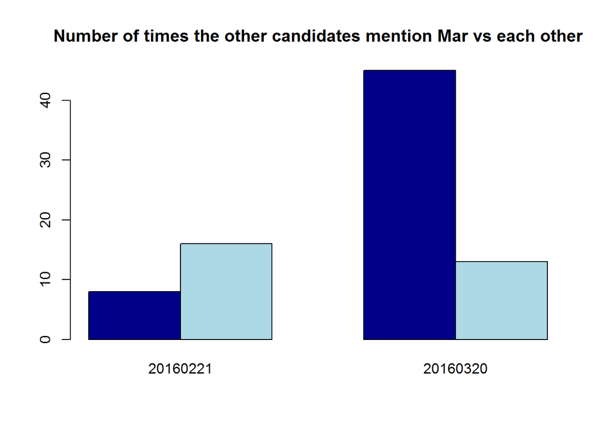

```r
barplot(n,main='Number of times the other candidates mention Mar vs each other',
        beside=TRUE,col=c('darkblue','lightblue'),
        #legend=c('# of times the other candidates mention Mar','# of times the other candidates mention each other'),
        legend.text = FALSE)
```

```r
n
```

```
##          20160221 20160320
## mar             8       45
## the_rest       16       13
```

```r
## Who mentioned Mar's name the most?
mar_binay = sapply(ref_list, function(df) sum(df[rownames(df) == 'BINAY', 'MAR']))
mar_binay
```

```
## 20160221 20160320
##        5       21
```

```r
mar_duterte = sapply(ref_list, function(df) sum(df[rownames(df) == 'DUTERTE', 'MAR']))
mar_duterte
```

```
## 20160221 20160320
##        0       14
```

```r
mar_poe = sapply(ref_list, function(df) sum(df[rownames(df) == 'POE', 'MAR']))
mar_poe
```

```
## 20160221 20160320
##        2       10
```

```r
mar_miriam = sapply(ref_list, function(df) sum(df[rownames(df) == 'MIRIAM', 'MAR']))
mar_miriam
```

```
## 20160221 20160320
##        1        0
```

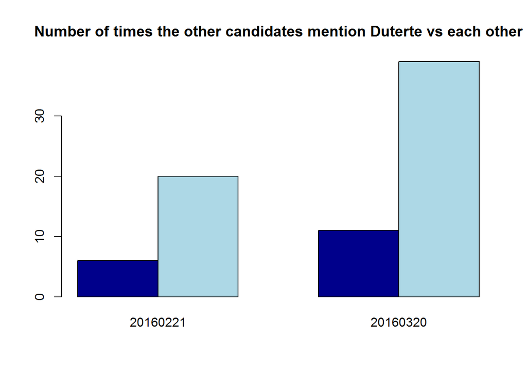

```r
barplot(o,main='Number of times the other candidates mention Duterte vs each other',
        beside=TRUE,col=c('darkblue','lightblue'),
        #legend=c('# of times the other candidates mention Duterte','# of times the other candidates mention each other'),
        legend.text = FALSE)
```

```r
o
```

```
##          20160221 20160320
## duterte         6       11
## the_rest       20       39
```

```r
p
```

```
##          20160221 20160320
## poe             2        1
## the_rest       18       45
```

```r
q
```

```
##          20160221 20160320
## miriam         10        1
## the_rest       16       63
```

Let’s now turn our attention to the words themselves…

```r
dates = c(20160221)
#collect all the transcripts in a single character string
read_transcript = function(date){scan(paste0('debate_', date, '_full', '.txt'), what='x', quote=NULL)}
#read and collate all transcripts
text = unlist(sapply(dates, read_transcript))

speakers =
  c(  BINAY    = '',
      MAR   = '',
      DUTERTE  = '',
      MIRIAM  = '',
      POE = ''
  )

#assign text to the right speaker
for(word in text){
  #if word ends with :
  if(substr(word,nchar(word),nchar(word))==':'){
    #if word corresponds to one of the speakers of interest
    if(word %in% paste0(names(speakers), ':')){
      #set current speaker
      currentSpeaker = substr(word,1,nchar(word)-1)
    }
    else{
      #if the current speaker is not one of the speakers of interest, set it to NA
      currentSpeaker = NA
    }
  }
  else if(!is.na(currentSpeaker)){
    #if the current speaker is of interest, save what he is saying
    speakers[currentSpeaker] = paste(speakers[currentSpeaker], word)
  }
}

##############################################################################
# The candidates' vocabularies are further simplified by removing common words
# that convey little meaning (e.g.,prepositions,pronouns) and stemming the
# remaining, more substantive words.
##############################################################################

#preprocess text
prez = Corpus(VectorSource(speakers))
prez = tm_map(prez, tolower)
prez = tm_map(prez, removeWords,stopwords('english'))
#remove additional unwanted words
prez = Corpus(VectorSource(speakers))
prez = tm_map(prez, tolower)
prez = tm_map(prez, removeWords,stopwords('english'))
#remove additional unwanted words
prez = tm_map(prez, removeWords, c('laughter', 'applause', 'intermission', 'and', 'the', 'all',
                                   'ang','mga','you','hindi','that','kung','ating','said','naman',
                                   'namin','natin','yung','pero','sila','nila','ako','yan','para',
                                   'will','isang','ito','doon','alam','may','kanilang','dahil',
                                   'lahat','have','tayo','kami','for','because','rin','ngayon',
                                   'kaya','kaya','hong','walang','but','kahit','dapat','lang',
                                   'mas','pwedeng','saan','yong','buong','yong','ayaw','lang',
                                   'not','wala','there','are','was','would','ano','well','can',
                                   'kasi','dito','our','akong','with','dun','gusto','ninyo',
                                   'bakit','niya','like','ibang','talagang','did','yes','yun','this',
                                   'anong','man','diyan','tulad','pwede','talaga','give','bilang','isa',
                                   'itong','what','nasa','sinasabi','just','kayo','lamang','nga','luchi',
                                   'mismo','other','akin','kanya','ikaw','cannot','aking','ginawa',
                                   'kanila','ginawa','know','really','sapagkat','din','maraming','they',
                                   'meron','roxas','duterte','poe','mar','miriam',
                                   'mong','uulitin','yon','yo','tony','below','anyway','eto','aba',
                                   'when','madam','amin','nandun','pagka','mahigit','senadora','sya',
                                   'inyong','parang','salamat','nagiging','yeah','look','how','goes','huwag','see','say',
                                   'kang','actually','sinabi','about','already','nung','importante',
                                   'oras','tama','here','very','into','pati','why','sabi','those','always',
                                   'has','first','ganoon','atin','dalawang','kailangan','papaano','sabihin',
                                   'nilang','hanggang','nating','from','siguro','tayong','naging','after',
                                   'siya','namang','nagsabi','nang','lagi','niyo','grace','nagsasabi','nyo',
                                   'pong','basta','dyan','iyan','pang','tayong','which','should','sino','these',
                                   'without','di','yang','ilang','noon','noong','pag','iyon','kong',
                                   'mag','maging','nandiyan','nang','per','pumunta','iyan','let','muna','each',
                                   'aming','sana','also','basta','ganito'))
prez = tm_map(prez, removePunctuation,preserve_intra_word_dashes=FALSE)
prez = tm_map(prez, stemDocument)
prez = tm_map(prez, stripWhitespace)
prez = tm_map(prez, removeNumbers)
prez = tm_map(prez, PlainTextDocument)
#make document term matrix
dtm_20160221 = DocumentTermMatrix(prez)
#reassign row names (each row is a speaker)
rownames(dtm_20160221) = names(speakers)
```

```r
#######################################
#For each candidate, what are the top 100 most frequent words ?
#######################################
# get indexes of 100 most frequent words
indexes = apply(dtm_20160221, 1, function(v) head(order(v, decreasing=TRUE), 100))
# find the 100 most frequent words
freq_words = apply(indexes, 2, function(v) colnames(dtm_20160221)[v])
#find the number of times each word appears in the matrix
word_count_freq = apply(freq_words, c(1,2), function(x) sum(x == freq_words))
unique_words_freq = word_count_freq >= 1
l_freq = lapply(colnames(freq_words), function(name) freq_words[unique_words_freq[,name], name])
names(l_freq) = colnames(freq_words)
```

```r
dates_2 = c(20160320)
#collect all the transcripts in a single character string
read_transcript_2 = function(date){scan(paste0('debate_', date, '_full', '.txt'), what='x', quote=NULL)}
#read and collate all transcripts
text_2 = unlist(sapply(dates_2, read_transcript_2))

speakers_2 =
  c(  BINAY    = '',
      MAR   = '',
      DUTERTE  = '',
      MIRIAM  = '',
      POE = ''
  )

#assign text to the right speaker
for(word in text_2){
  #if word ends with :
  if(substr(word,nchar(word),nchar(word))==':'){
    #if word corresponds to one of the speakers of interest
    if(word %in% paste0(names(speakers_2), ':')){
      #set current speaker
      currentSpeaker = substr(word,1,nchar(word)-1)
    }
    else{
      #if the current speaker is not one of the speakers of interest, set it to NA
      currentSpeaker = NA
    }
  }
  else if(!is.na(currentSpeaker)){
    #if the current speaker is of interest, save what he is saying
    speakers_2[currentSpeaker] = paste(speakers_2[currentSpeaker], word)
  }
}

##############################################################################
# The candidates' vocabularies are further simplified by removing common words
# that convey little meaning (e.g.,prepositions,pronouns) and stemming the
# remaining, more substantive words.
##############################################################################

#preprocess text
prez_2 = Corpus(VectorSource(speakers_2))
prez_2 = tm_map(prez_2, tolower)
prez_2 = tm_map(prez_2, removeWords,stopwords('english'))
#remove additional unwanted words
prez_2 = Corpus(VectorSource(speakers_2))
prez_2 = tm_map(prez_2, tolower)
prez_2 = tm_map(prez_2, removeWords,stopwords('english'))
#remove additional unwanted words
prez_2 = tm_map(prez_2, removeWords, c('laughter', 'applause', 'intermission', 'and', 'the', 'all',
                                   'ang','mga','you','hindi','that','kung','ating','said','naman',
                                   'namin','natin','yung','pero','sila','nila','ako','yan','para',
                                   'will','isang','ito','doon','alam','may','kanilang','dahil',
                                   'lahat','have','tayo','kami','for','because','rin','ngayon',
                                   'kaya','kaya','hong','walang','but','kahit','dapat','lang',
                                   'mas','pwedeng','saan','yong','buong','yong','ayaw','lang',
                                   'not','wala','there','are','was','would','ano','well','can',
                                   'kasi','dito','our','akong','with','dun','gusto','ninyo',
                                   'bakit','niya','like','ibang','talagang','did','yes','yun','this',
                                   'anong','man','diyan','tulad','pwede','talaga','give','bilang','isa',
                                   'itong','what','nasa','sinasabi','just','kayo','lamang','nga','luchi',
                                   'mismo','other','akin','kanya','ikaw','cannot','aking','ginawa',
                                   'kanila','ginawa','know','really','sapagkat','din','maraming','they',
                                   'meron','roxas','duterte','poe','mar','miriam',
                                   'mong','uulitin','yon','yo','tony','below','anyway','eto','aba',
                                   'when','madam','amin','nandun','pagka','mahigit','senadora','sya',
                                   'inyong','parang','salamat','nagiging','yeah','look','how','goes','huwag','see','say',
                                   'kang','actually','sinabi','about','already','nung','importante',
                                   'oras','tama','here','very','into','pati','why','sabi','those','always',
                                   'has','first','ganoon','atin','dalawang','kailangan','papaano','sabihin',
                                   'nilang','hanggang','nating','from','siguro','tayong','naging','after',
                                   'siya','namang','nagsabi','nang','lagi','niyo','grace','nagsasabi','nyo',
                                   'pong','basta','dyan','iyan','pang','tayong','which','should','sino','these',
                                   'without','di','yang','ilang','noon','noong','pag','iyon','kong',
                                   'mag','maging','nandiyan','nang','per','pumunta','iyan','let','muna','each',
                                   'aming','sana','also','basta','ganito'))
prez_2 = tm_map(prez_2, removePunctuation,preserve_intra_word_dashes=FALSE)
prez_2 = tm_map(prez_2, stemDocument)
prez_2 = tm_map(prez_2, stripWhitespace)
prez_2 = tm_map(prez_2, removeNumbers)
prez_2 = tm_map(prez_2, PlainTextDocument)
#make document term matrix
dtm_20160320 = DocumentTermMatrix(prez_2)
#reassign row names (each row is a speaker)
rownames(dtm_20160320) = names(speakers_2)
```

```r
#######################################
#For each candidate, what are the top 100 most frequent words ?
#######################################
# get indexes of 100 most frequent words
indexes_2 = apply(dtm_20160320, 1, function(v) head(order(v, decreasing=TRUE), 100))
# find the 100 most frequent words
freq_words_2 = apply(indexes_2, 2, function(v) colnames(dtm_20160320)[v])
#find the number of times each word appears in the matrix
word_count_freq_2 = apply(freq_words_2, c(1,2), function(x) sum(x == freq_words_2))
unique_words_freq_2 = word_count_freq_2 >= 1
l_freq_2 = lapply(colnames(freq_words_2), function(name) freq_words_2[unique_words_freq_2[,name], name])
names(l_freq_2) = colnames(freq_words_2)
```

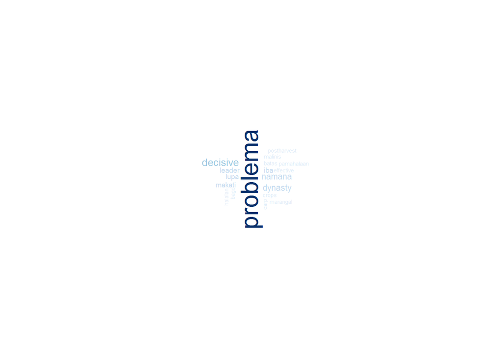

```r
###########
#WORDCLOUDS
###########
freq_binay_20160221 = dtm_20160221['BINAY', l_freq$BINAY]
#freq_binay_20160320 = dtm_20160320['BINAY', l_freq_2$BINAY]

freq_duterte_20160221 = dtm_20160221['DUTERTE', l_freq$DUTERTE]
#freq_duterte_20160320 = dtm_20160320['DUTERTE', l_freq_2$DUTERTE]

freq_poe_20160221 = dtm_20160221['POE', l_freq$POE]
#freq_poe_20160320 = dtm_20160320['POE', l_freq_2$POE]

freq_mar_20160221 = dtm_20160221['MAR', l_freq$MAR]
#freq_mar_20160320 = dtm_20160320['MAR', l_freq_2$MAR]

freq_miriam_20160221 = dtm_20160221['MIRIAM', l_freq$MIRIAM]
#freq_miriam_20160320 = dtm_20160320['MIRIAM', l_freq_2$MIRIAM]


wordcloud(l_freq$BINAY, as.vector(freq_binay_20160221),random.order=FALSE,scale=c(2,.1),
          rot.per=.15,colors=brewer.pal(9,'Blues'))
```

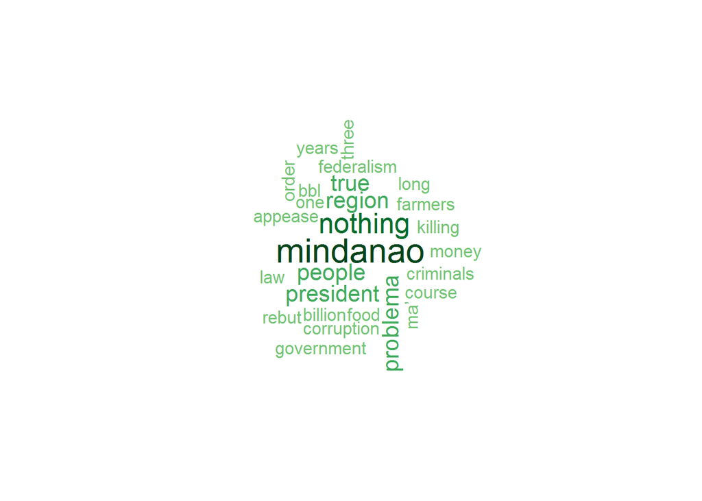

```r
#wordcloud(l_freq_2$BINAY, as.vector(freq_binay_20160320),random.order=FALSE,scale=c(2,.1),
#         rot.per=.15,colors=brewer.pal(9,'Blues'))


wordcloud(l_freq$DUTERTE, as.vector(freq_duterte_20160221),random.order=FALSE,scale=c(2,.1),
          rot.per=.15,colors=brewer.pal(9,'Greens'))
```

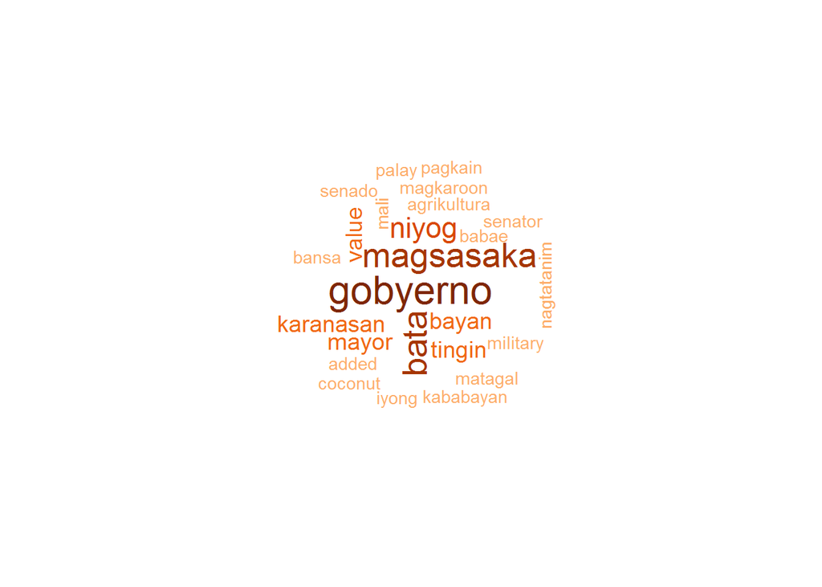

```r
# wordcloud(l_freq_2$DUTERTE, as.vector(freq_duterte_20160320),random.order=FALSE,scale=c(2,.1),
#           rot.per=.15,colors=brewer.pal(9,'Greens'))

wordcloud(l_freq$POE, as.vector(freq_poe_20160221),random.order=FALSE,scale=c(2,.1),
          rot.per=.15, colors=brewer.pal(9,'Oranges'))
```

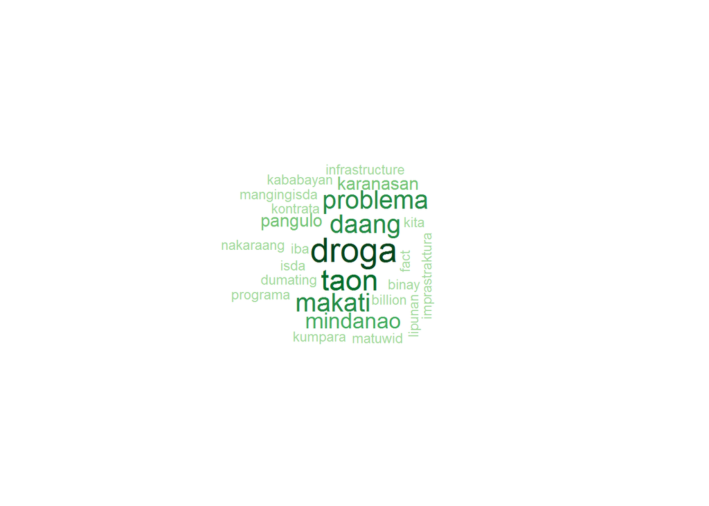

```r
# wordcloud(l_freq_2$POE, as.vector(freq_poe_20160320),random.order=FALSE,scale=c(2,.1),
#           rot.per=.15, colors=brewer.pal(9,'Oranges'))

wordcloud(l_freq$MAR, as.vector(freq_mar_20160221),random.order=FALSE,scale=c(2,.1),
          rot.per=.15, colors=brewer.pal(9,'Greens'))
```

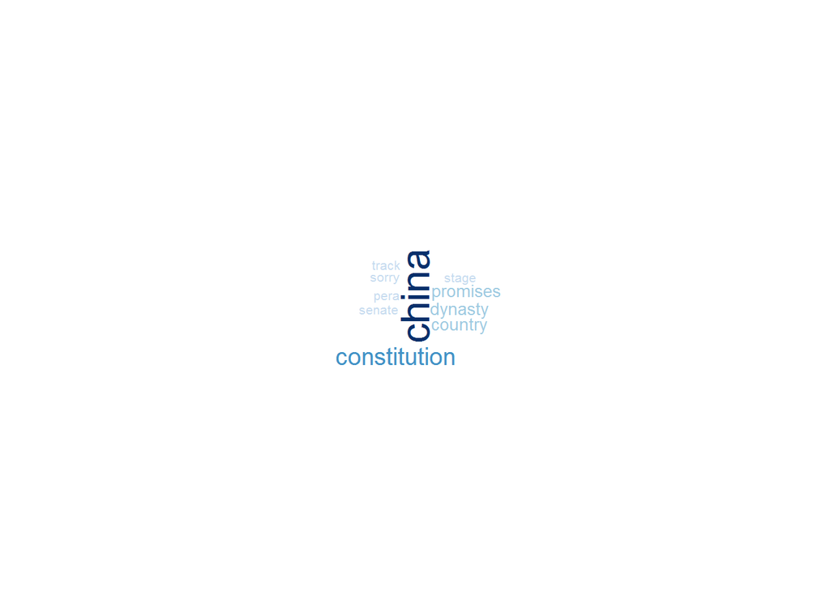

```r
# wordcloud(l_freq_2$MAR, as.vector(freq_mar_20160320),random.order=FALSE,scale=c(2,.1),
#           rot.per=.15, colors=brewer.pal(9,'Greens'))

wordcloud(l_freq$MIRIAM, as.vector(freq_miriam_20160221),random.order=FALSE,scale=c(2,.1),
          rot.per=.15, colors=brewer.pal(9,'Blues'))
```

```r
# wordcloud(l_freq_2$MIRIAM, as.vector(freq_miriam_20160320),random.order=FALSE,scale=c(2,.1),
#           rot.per=.15, colors=brewer.pal(9,'Blues'))
```